[figure not shown]

This dashboard is designed to help you focus your efforts at practice engineering or other activities to optimize the chance you earn shared savings in 2019. The charts below summarize your performance in 4 areas which are critical to the ACO’s success.

##### **Provider Overview**

| Clinician Name | Num of Non OptOut Patient | Avg RAF Score | Avg Cost Per Patient | Avg Expected Expenditure Per Patient | Total Cost |
| --- | --- | --- | --- | --- | --- |
| RAMIN MEHDIAN | 139 | 1.43 | $ 9,256.45 | $ 9,237.466 | $ 1,147,799 |

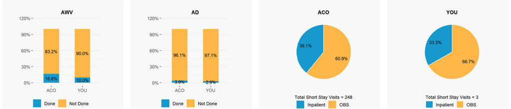

Goal 1: 100% of beneficiaries receive Annual Wellness Visit and Advance Directive Counseling.  
Goal 2: Admit to observation whenever appropriate (0-1 Midnights)

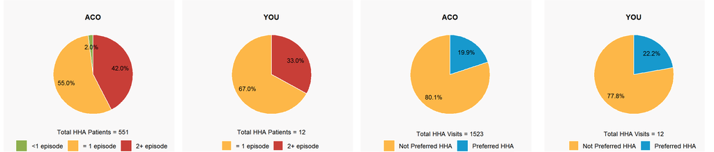

Goal 3A: Certify 0-4 home health visits whenever appropriate.  
Goal 3B: Usage of Preferred Home Health Agencies – ASSISTED HOME CARE & LOS ROBLES HOMECARE SERVICES INC THOUSAND SERVICES.

[figure not shown]

This dashboard is designed to help you focus your efforts at practice engineering or other activities to optimize the chance you earn shared savings in 2019. The charts below summarize your performance in 4 areas which are critical to the ACO’s success.

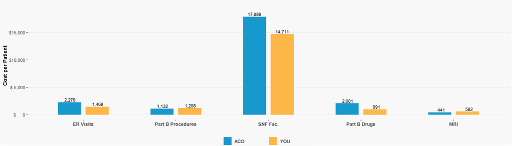

[output not shown]

Goal 4: Reduced costs in areas the VCFMC ACO has significantly higher costs than the national ACO Average  
Based on our analytics, the data show the expense/utilization of your patients compared to other ACO physicians/clinicians as shown above. We understand there will be an obvious medical need for these expenses in many cases but we suggest you review the data for areas where your expenses are higher than ACO average to see where you might focus your efforts to provide care which is both **excellent** and **efficient**.